# Coursera Milestone Report

Zach Christensen

July 17, 2015

## Summary

This report is a progress update on the creation of a text predication app being created for the John Hopkins Data Science Specialization on Coursera. This report outlines the work completed to load and clean the data as well as the initial exploratory analysis completed.

## Data Processing

#### Load Libraries

```r
library(tm)
library(SnowballC)
library(RWeka)
library(reshape)
library(dplyr)
library(ggplot2)
library(gridExtra)
library(wordcloud)
```

#### Examine Dataset

```r
files <- c("final/en_US/en_US.blogs.txt", "final/en_US/en_US.news.txt", "final/en_US/en_US.twitter.txt")

## Examine files for number of lines and size
counts <- c()
fileSize <- c()
for (i in 1:length(files)) {
  com <- paste("wc -l ", files[i], " | awk '{ print $1 }'", sep="")
  counts <- c(counts, paste(system(command=com, intern=TRUE), "lines"))
  fileSize <- c(fileSize, paste(as.integer((file.info(files[i])$size) / (1024 ^ 2)), "Mbs"))
}
cbind(files, counts, fileSize)
```

```
##      files                           counts          fileSize
## [1,] "final/en_US/en_US.blogs.txt"   "899288 lines"  "200 Mbs"
## [2,] "final/en_US/en_US.news.txt"    "1010242 lines" "196 Mbs"
## [3,] "final/en_US/en_US.twitter.txt" "2360148 lines" "159 Mbs"
```

#### Sample Data

The following function is used to sample data from the files, reading a set number of lines and loading that data into a corpus. This corpus is then cleaned using the `tm` library, removing spaces, numbers, punctuation, and whitespace. The document is then stemmed using the `SnowballC` library.

```r
text <- c()

for (i in 1:length(files)) {
  ## open the file, read the text into memory, and close connection
  con <- file(files[i])
  text <- c(text, readLines(con, 1000))
  close(con)
}

corpus <- Corpus(VectorSource(text))
rm(text)

## Replace some special characters with a space
toSpace <- content_transformer(function(x, pattern) {
  gsub(pattern, " ", x)
})
corpus <- tm_map(corpus, toSpace, "/|@|\\|")

## convert to lower case, remove numbers and punctuation
corpus <- tm_map(corpus, content_transformer(tolower))

## remove stopwords before punctuation removed
corpus <- tm_map(corpus, removeWords, stopwords("english"))

## remove numbers, punctuation, and whitespace
corpus <- tm_map(corpus, removeNumbers)
corpus <- tm_map(corpus, removePunctuation)
corpus <- tm_map(corpus, stripWhitespace)

## Stem the document with SnowballC
corpus <- tm_map(corpus, stemDocument)

inspect(corpus[c(50,1050,2050)])
```

```
## <<VCorpus (documents: 3, metadata (corpus/indexed): 0/0)>>
##
## [[1]]
## <<PlainTextDocument (metadata: 7)>>
##  lovin peopl benefit good back band consist pretti purdi drum arti butler organ piano joe mack bill salter bass band play loos funki without ever sound sloppi help produc laid back vibe chandler sound relax earlier album better song one titl cut warm poppi number well lovin peopl presenc chorus m…
##
## [[2]]
## <<PlainTextDocument (metadata: 7)>>
## anoth strong month hire make less like feder reserv will take addit step boost economi meet next week
##
## [[3]]
## <<PlainTextDocument (metadata: 7)>>
## william davi attorney say client will plead insan face firstdegre murder charg woman death
```

The corpus contains the 3000 lines read from the files, each stored as a document. As shown above, the text has been processed to some extent, the most notable change being the lack of `stop words` and word endings (the result of stemming).

## Exploratory Analysis

#### Document Length

Given the three different sources of text, there will likely be some variation in the length of documents (number of words). Below the input is grouped by source type (1000 lines from each type), and some summary statistics are calculated.

```r
type <- c(rep("blogs", 1000), rep("news", 1000), rep("tweets", 1000))

termCount <- colSums(as.matrix(TermDocumentMatrix(corpus)))
termCount <- data.frame(termCount, type, stringsAsFactors = FALSE)

termCount %>% group_by(type) %>% summarize(mean = mean(termCount), max = max(termCount))
```

```
## Source: local data frame [3 x 3]
##
##     type   mean max
## 1  blogs 20.866 197
## 2   news 18.557  85
## 3 tweets  6.723  20
```

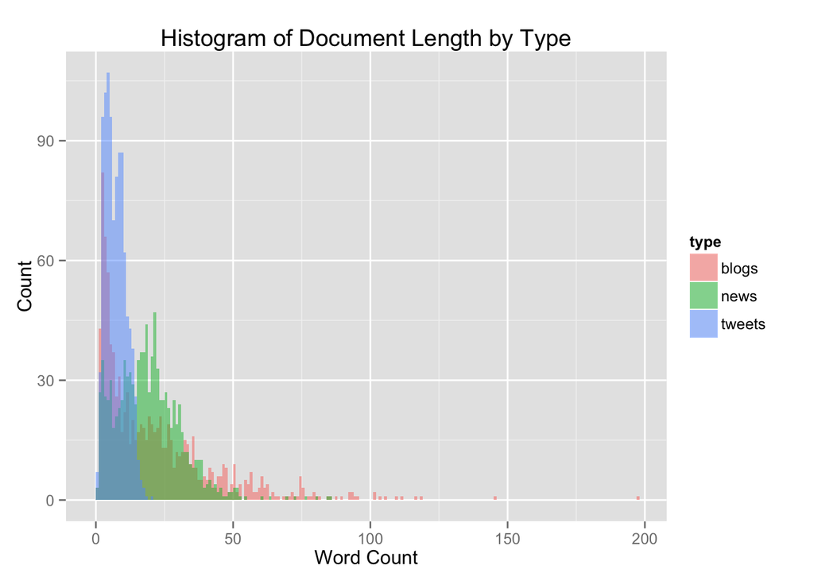

```r
ggplot(termCount, aes(termCount, fill = type)) + geom_histogram(alpha = 0.5, position = 'identity', binwidth = 1) + labs(title = "Histogram of Document Length by Type", x = "Word Count", y = "Count")
```

As shown above, tweets are, on average, the shortest document type and blogs are, on average, the longest.

#### ngrams

Ngrams are created from each data source to examine the most common word groups.

```r
blog_corpus <- unlist(sapply(corpus[1:1000],`[`, "content"))
blog_bigrams <- NGramTokenizer(blog_corpus, control = Weka_control(max = 2, min = 2))
blog_trigrams <- NGramTokenizer(blog_corpus, control = Weka_control(max = 3, min = 3))

news_corpus <- unlist(sapply(corpus[1001:2000],`[`, "content"))
news_bigrams <- NGramTokenizer(news_corpus, control = Weka_control(max = 2, min = 2))
news_trigrams <- NGramTokenizer(news_corpus, control = Weka_control(max = 3, min = 3))

tweet_corpus <- unlist(sapply(corpus[2001:3000],`[`, "content"))
tweet_bigrams <- NGramTokenizer(tweet_corpus, control = Weka_control(max = 2, min = 2))
tweet_trigrams <- NGramTokenizer(tweet_corpus, control = Weka_control(max = 3, min = 3))

## Used to find top ten
topTen <- function(ngram) {
  tableNgram <- data.frame(table(ngram))
  tableNgram[order(tableNgram$Freq, decreasing = TRUE),][1:10,]
}

ten_blog_bigram <- topTen(blog_bigrams)
ten_blog_trigram <- topTen(blog_trigrams)

ten_news_bigram <- topTen(news_bigrams)
ten_news_trigram <- topTen(news_trigrams)

ten_tweet_bigram <- topTen(tweet_bigrams)
ten_tweet_trigram <- topTen(tweet_trigrams)
```

Histogram of top words from each source:

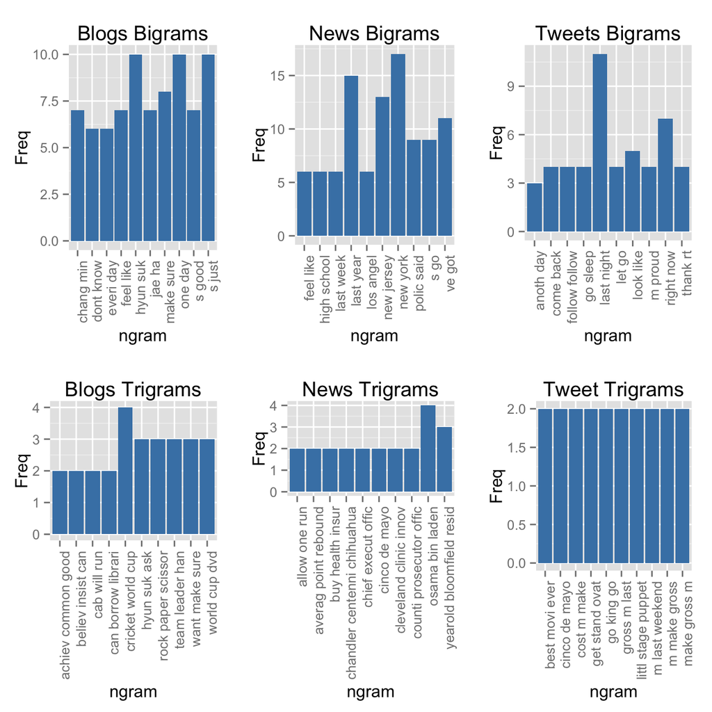

```r
grid.arrange(ggplot(data=ten_blog_bigram, aes(x=ngram, y=Freq)) +
      geom_bar(fill="steelblue", stat="identity") + labs(title = "Blogs Bigrams") +
      guides(fill=FALSE) + theme(axis.text.x = element_text(angle = 90, hjust = 1)),
    ggplot(data=ten_news_bigram, aes(x=ngram, y=Freq)) +
      geom_bar(fill="steelblue", stat="identity") + labs(title = "News Bigrams") +
      guides(fill=FALSE) + theme(axis.text.x = element_text(angle = 90, hjust = 1)),
    ggplot(data=ten_tweet_bigram, aes(x=ngram, y=Freq)) +
      geom_bar(fill="steelblue", stat="identity") + labs(title = "Tweets Bigrams") +
      guides(fill=FALSE) + theme(axis.text.x = element_text(angle = 90, hjust = 1)),
    ggplot(data=ten_blog_trigram, aes(x=ngram, y=Freq)) +
      geom_bar(fill="steelblue", stat="identity") + labs(title = "Blogs Trigrams") +
      guides(fill=FALSE) + theme(axis.text.x = element_text(angle = 90, hjust = 1)),
    ggplot(data=ten_news_trigram, aes(x=ngram, y=Freq)) +
      geom_bar(fill="steelblue", stat="identity") + labs(title = "News Trigrams") +
      guides(fill=FALSE) + theme(axis.text.x = element_text(angle = 90, hjust = 1)),
    ggplot(data=ten_tweet_trigram, aes(x=ngram, y=Freq)) +
      geom_bar(fill="steelblue", stat="identity") + labs(title = "Tweet Trigrams") +
      guides(fill=FALSE) + theme(axis.text.x = element_text(angle = 90, hjust = 1)),
    nrow=2)
```

#### Word Cloud

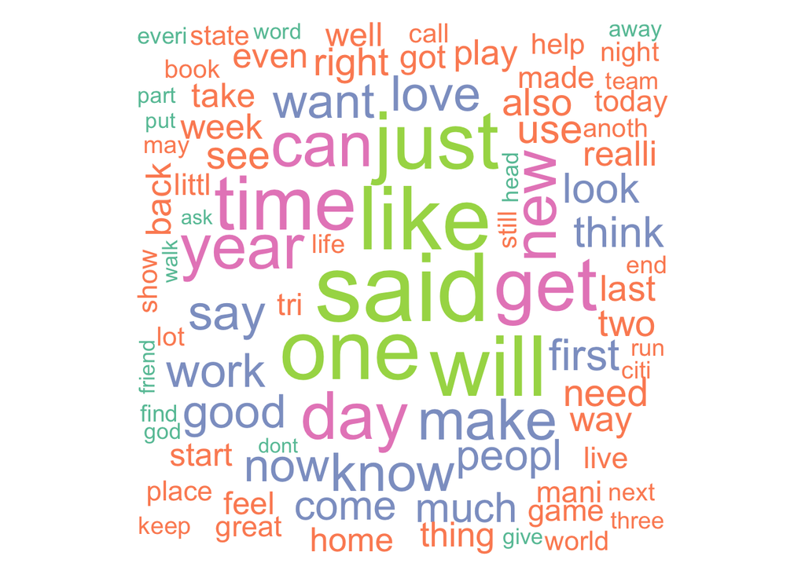

```r
tdm <- as.matrix(TermDocumentMatrix(corpus))
freqs<-rowSums(tdm)

wc_df <- data.frame(word = names(freqs), count = freqs)
wordcloud(wc_df$word, wc_df$count, c(5, 0.3), 50, random.order = FALSE, colors = brewer.pal(5, "Set2"))
```

## Predication Algorithm

The plan for the predication algorithm is to generate multiple ngrams from a sample of the input files. These ngrams will be of length one to five (unigrams to pentagrams). The algorithm will provide the most weight to the long ngrams, since these will have the most *context* for the predication; shorter ngrams will influence the results based on frequencies of word groupings (or individual words for the unigrams).